# Multi-Modal Module Model Estimation Summary Alt Modes

Prepared by RSG, Inc.

April 14, 2022

# Bike, Walk, and Transit Models

## Estimation Data

### Data Sources

Data used to estimate the VE-MM models for bike, walk, and transit use came from the same sources as were used by AADVMT model. The 2017 NHTS confidential data with Census Block Group attached were again used to link to the EPA Smart Location Database, version 3 (SLD). Additional spatial information at the metropolitan area level were added to the data including transit revenue miles from the National Transit Database and freeway lane miles from FHWA published data.

### Bike, Walk, and Transit Usage Data

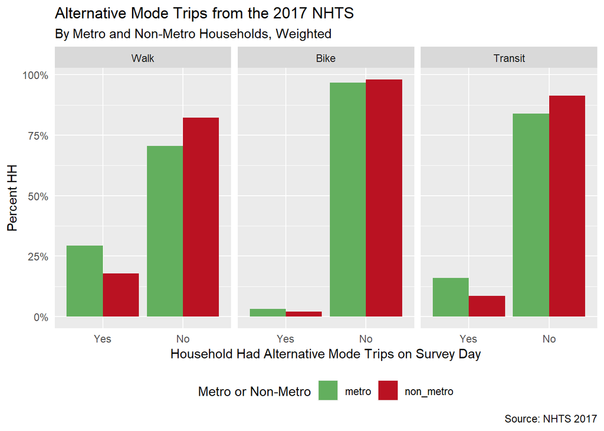

Figure 1: Proportion of households in the 2017 NHTS that made Bike, Walk, and Transit Trips on the Survey Day

The chart below summarises the distribution of the number of daily trips by each household that does make walk, bike, or transit trip respectively. The second column of charts shows the distibution in the total daily person miles traveled by household for those households that do make trips by the alternative modes. The third column shows the distribution in average trip lengths by household.

For the number of trips, two trips is the most common number, with four trips also appearing frequently. A single trip is also common, especially for walking. For daily person miles traveled, as is expected walking mileage is the lowest, followed by biking and then transit. Most walk trips are less than a miles, with most bike trips less than 5 miles, and most transit trips less than 20 miles.

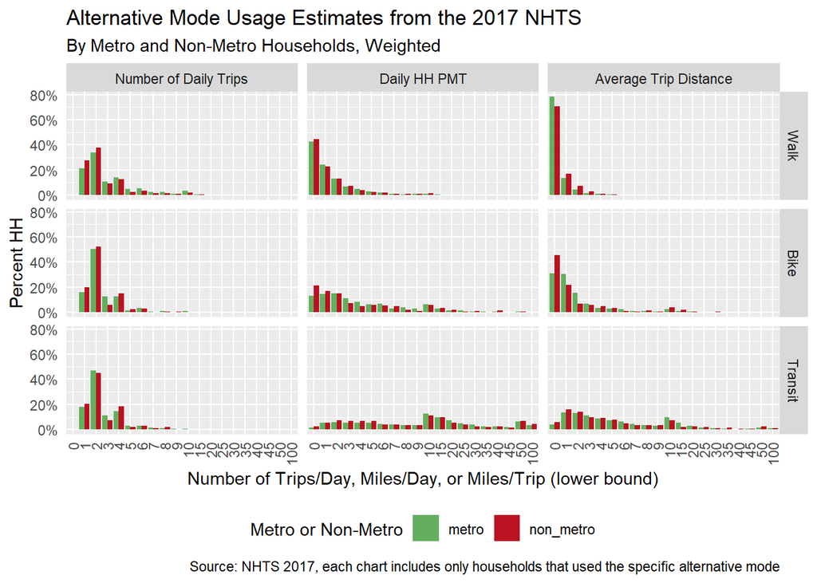

Figure 2: Summary of 2017 NHTS Bike, Walk, and Transit Trips

## Model Estimation

### 2017 NHTS Bike PMT Model

The following table shows the Bike PMT model estimated using the 2017 NHTS for Metro areas and Non-Metro area.

Table 1: Bike PMT Hurdle Model for Metro Areas, Zero Model

|  | Estimate | Std. Error | z value | Pr(>\|z\|) |
| --- | --- | --- | --- | --- |
| (Intercept) | -3.260 | 0.104 | -31.256 | 0.000 |
| AADVMT | -0.004 | 0.000 | -9.017 | 0.000 |
| Workers | 0.214 | 0.028 | 7.595 | 0.000 |
| LifeCycleCouple w/o children | 0.100 | 0.057 | 1.743 | 0.081 |
| LifeCycleEmpty Nester | -0.694 | 0.081 | -8.602 | 0.000 |
| LifeCycleSingle | -0.169 | 0.070 | -2.428 | 0.015 |
| Age0to14 | 0.247 | 0.030 | 8.255 | 0.000 |
| CENSUS_RNE | -0.124 | 0.072 | -1.726 | 0.084 |
| CENSUS_RS | -0.238 | 0.060 | -3.959 | 0.000 |
| CENSUS_RW | 0.328 | 0.058 | 5.665 | 0.000 |
| D1B | -0.001 | 0.001 | -0.491 | 0.623 |
| D5 | 0.018 | 0.002 | 8.022 | 0.000 |
| FwyLaneMiPC | -332.319 | 84.456 | -3.935 | 0.000 |
| TranRevMiPC | -0.416 | 1.942 | -0.214 | 0.830 |
| D1B:D2A_EPHHM | 0.000 | 0.002 | 0.135 | 0.893 |

Table 2: Bike PMT Hurdle Model for Metro Areas, Count Model

|  | Estimate | Std. Error | z value | Pr(>\|z\|) |
| --- | --- | --- | --- | --- |
| (Intercept) | 1.412 | 0.047 | 30.268 | 0.000 |
| AADVMT | 0.002 | 0.000 | 18.684 | 0.000 |
| Workers | 0.066 | 0.011 | 5.837 | 0.000 |
| VehPerDriver | 0.045 | 0.018 | 2.552 | 0.011 |
| LifeCycleCouple w/o children | 0.436 | 0.024 | 17.819 | 0.000 |
| LifeCycleEmpty Nester | 0.387 | 0.034 | 11.245 | 0.000 |
| LifeCycleSingle | 0.868 | 0.028 | 31.423 | 0.000 |
| Age0to14 | -0.056 | 0.015 | -3.816 | 0.000 |
| CENSUS_RNE | -0.321 | 0.027 | -11.924 | 0.000 |
| CENSUS_RS | -0.337 | 0.024 | -14.305 | 0.000 |
| CENSUS_RW | -0.215 | 0.021 | -10.011 | 0.000 |
| D1B | -0.009 | 0.001 | -13.584 | 0.000 |
| D2A_EPHHM | 0.080 | 0.044 | 1.828 | 0.068 |
| FwyLaneMiPC | -60.382 | 30.932 | -1.952 | 0.051 |
| D4c | -0.004 | 0.001 | -6.316 | 0.000 |
| D1B:D2A_EPHHM | 0.027 | 0.001 | 23.373 | 0.000 |
| D4c:TranRevMiPC | 0.047 | 0.015 | 3.199 | 0.001 |

Table 3: Bike PMT Hurdle Model for Metro Areas, Statistics

| Statistic | Values |
| --- | --- |
| Observations | 72357 |
| Log-likelihood | -24586 |
| Iterations | 64 |

Table 4: Bike PMT Hurdle Model for Non-Metro Areas, Zero Model

|  | Estimate | Std. Error | z value | Pr(>\|z\|) |
| --- | --- | --- | --- | --- |
| (Intercept) | -3.569 | 0.134 | -26.585 | 0.000 |
| AADVMT | -0.004 | 0.001 | -5.426 | 0.000 |
| Workers | 0.032 | 0.047 | 0.687 | 0.492 |
| LifeCycleCouple w/o children | -0.504 | 0.105 | -4.779 | 0.000 |
| LifeCycleEmpty Nester | -0.963 | 0.117 | -8.237 | 0.000 |
| LifeCycleSingle | -0.641 | 0.125 | -5.130 | 0.000 |
| Age0to14 | 0.277 | 0.041 | 6.829 | 0.000 |
| D1B | 0.000 | 0.004 | 0.012 | 0.990 |
| D2A_EPHHM | 0.148 | 0.161 | 0.917 | 0.359 |
| D3bpo4 | 0.007 | 0.001 | 7.459 | 0.000 |
| D5 | 0.122 | 0.037 | 3.292 | 0.001 |

Table 5: Bike PMT Hurdle Model for Non-Metro Areas, Count Model

|  | Estimate | Std. Error | z value | Pr(>\|z\|) |
| --- | --- | --- | --- | --- |
| (Intercept) | 2.607 | 0.077 | 34.011 | 0.000 |
| AADVMT | -0.001 | 0.000 | -3.060 | 0.002 |
| HhSize | -0.198 | 0.018 | -11.144 | 0.000 |
| LifeCycleCouple w/o children | -0.169 | 0.055 | -3.099 | 0.002 |
| LifeCycleEmpty Nester | -0.012 | 0.066 | -0.189 | 0.850 |
| LifeCycleSingle | 0.037 | 0.067 | 0.548 | 0.584 |
| Age0to14 | 0.007 | 0.024 | 0.305 | 0.761 |
| Age65Plus | -0.218 | 0.036 | -6.098 | 0.000 |
| D1B | 0.045 | 0.007 | 6.557 | 0.000 |
| D3bpo4 | -0.006 | 0.001 | -7.106 | 0.000 |
| D1B:D2A_EPHHM | -0.157 | 0.017 | -9.276 | 0.000 |

Table 6: Bike PMT Hurdle Model for Non-Metro Areas, Statistics

| Statistic | Values |
| --- | --- |
| Observations | 57230 |
| Log-likelihood | -8642 |
| Iterations | 42 |

The following tables compare the Bike PMT models estimated using the 2009 and 2017 NHTS.

This first comparison is between 2009 and 2017 Bike PMT Models for Metro areas.

Table 7: Bike PMT Hurdle Model for Metro Areas, Zero Model, Comparison of Models Estimated Using 2009 and 2017 NHTS Data

| VarName | NHTS2009 | NHTS2017 | Ratio |
| --- | --- | --- | --- |
| (Intercept) | -3.378 | -3.260 | 0.965 |
| AADVMT | -0.003 | -0.004 | 1.467 |
| Age0to14 | 0.407 | 0.247 | 0.608 |
| CENSUS_RNE | -0.723 | -0.124 | 0.171 |
| CENSUS_RS | -0.104 | -0.238 | 2.281 |
| CENSUS_RW | 0.050 | 0.328 | 6.533 |
| D1B | -0.013 | -0.001 | 0.041 |
| D1B:D2A_EPHHM | 0.010 | 0.000 | 0.031 |
| D5 | 0.025 | 0.018 | 0.715 |
| FwyLaneMiPC | -714.865 | -332.319 | 0.465 |
| LifeCycleCouple w/o children | 0.000 | 0.100 | Inf |
| LifeCycleEmpty Nester | -0.374 | -0.694 | 1.853 |
| LifeCycleParents w/ children | 0.562 | 0.000 | 0.000 |
| LifeCycleSingle | -0.855 | -0.169 | 0.198 |
| TranRevMiPC | -5.816 | -0.416 | 0.072 |
| Workers | 0.331 | 0.214 | 0.646 |

Table 8: Bike PMT Hurdle Model for Metro Areas, Count Model, Comparison of Models Estimated Using 2009 and 2017 NHTS Data

| VarName | NHTS2009 | NHTS2017 | Ratio |
| --- | --- | --- | --- |
| (Intercept) | 1.819 | 1.412 | 0.776 |
| AADVMT | 0.002 | 0.002 | 0.934 |
| Age0to14 | -0.175 | -0.056 | 0.320 |
| CENSUS_RNE | -0.008 | -0.321 | 42.627 |
| CENSUS_RS | 0.193 | -0.337 | -1.749 |
| CENSUS_RW | 0.239 | -0.215 | -0.899 |
| D1B | 0.014 | -0.009 | -0.683 |
| D1B:D2A_EPHHM | -0.033 | 0.027 | -0.824 |
| D2A_EPHHM | 0.171 | 0.080 | 0.467 |
| D4c | -0.002 | -0.004 | 2.268 |
| D4c:TranRevMiPC | 0.149 | 0.047 | 0.316 |
| FwyLaneMiPC | -187.799 | -60.382 | 0.322 |
| LifeCycleCouple w/o children | 0.000 | 0.436 | Inf |
| LifeCycleEmpty Nester | -0.426 | 0.387 | -0.910 |
| LifeCycleParents w/ children | -0.501 | 0.000 | 0.000 |
| LifeCycleSingle | -0.347 | 0.868 | -2.499 |
| VehPerDriver | 0.000 | 0.045 | -529.624 |
| Workers | 0.103 | 0.066 | 0.643 |

This second comparison is between 2009 and 2017 Bike PMT Models for Non-Metro areas.

Table 9: Bike PMT Hurdle Model for Non-Metro Areas, Zero Model, Comparison of Models Estimated Using 2009 and 2017 NHTS Data

| VarName | NHTS2009 | NHTS2017 | Ratio |
| --- | --- | --- | --- |
| (Intercept) | -4.425 | -3.569 | 0.807 |
| AADVMT | -0.003 | -0.004 | 1.261 |
| Age0to14 | 0.336 | 0.277 | 0.825 |
| D1B | 0.019 | 0.000 | 0.002 |
| D2A_EPHHM | 0.235 | 0.148 | 0.628 |
| D3bpo4 | 0.005 | 0.007 | 1.535 |
| D5 | -0.037 | 0.122 | -3.280 |
| LifeCycleCouple w/o children | 0.000 | -0.504 | -Inf |
| LifeCycleEmpty Nester | 0.169 | -0.963 | -5.693 |
| LifeCycleParents w/ children | 1.186 | 0.000 | 0.000 |
| LifeCycleSingle | -0.146 | -0.641 | 4.404 |
| Workers | 0.100 | 0.032 | 0.322 |

Table 10: Bike PMT Hurdle Model for Non-Metro Areas, Count Model, Comparison of Models Estimated Using 2009 and 2017 NHTS Data

| VarName | NHTS2009 | NHTS2017 | Ratio |
| --- | --- | --- | --- |
| (Intercept) | 2.049 | 2.607 | 1.272 |
| AADVMT | 0.001 | -0.001 | -0.960 |
| Age0to14 | -0.267 | 0.007 | -0.027 |
| Age65Plus | 0.149 | -0.218 | -1.463 |
| D1B | 0.042 | 0.045 | 1.070 |
| D1B:D2A_EPHHM | -0.093 | -0.157 | 1.692 |
| D3bpo4 | 0.004 | -0.006 | -1.698 |
| HhSize | 0.102 | -0.198 | -1.935 |
| LifeCycleCouple w/o children | 0.000 | -0.169 | -Inf |
| LifeCycleEmpty Nester | -0.364 | -0.012 | 0.034 |
| LifeCycleParents w/ children | -0.846 | 0.000 | 0.000 |
| LifeCycleSingle | -0.387 | 0.037 | -0.095 |

### 2017 NHTS Walk PMT Model

The following table shows the Walk PMT model estimated using the 2017 NHTS for Metro areas and Non-Metro area.

Table 11: Walk PMT Hurdle Model for Metro Areas, Zero Model

|  | Estimate | Std. Error | z value | Pr(>\|z\|) |
| --- | --- | --- | --- | --- |
| (Intercept) | -1.153 | 0.034 | -33.709 | 0.000 |
| AADVMT | -0.004 | 0.000 | -19.876 | 0.000 |
| Workers | 0.119 | 0.012 | 10.001 | 0.000 |
| LifeCycleCouple w/o children | -0.136 | 0.025 | -5.543 | 0.000 |
| LifeCycleEmpty Nester | -0.353 | 0.029 | -12.257 | 0.000 |
| LifeCycleSingle | -0.481 | 0.028 | -16.928 | 0.000 |
| Age0to14 | 0.094 | 0.014 | 6.583 | 0.000 |
| CENSUS_RNE | 0.057 | 0.027 | 2.083 | 0.037 |
| CENSUS_RS | -0.092 | 0.023 | -4.031 | 0.000 |
| CENSUS_RW | 0.034 | 0.024 | 1.412 | 0.158 |
| D3bpo4 | 0.004 | 0.000 | 16.899 | 0.000 |
| D5 | 0.034 | 0.002 | 15.908 | 0.000 |
| TranRevMiPC | 11.918 | 0.738 | 16.139 | 0.000 |
| D1B:D2A_EPHHM | 0.015 | 0.001 | 17.541 | 0.000 |

Table 12: Walk PMT Hurdle Model for Metro Areas, Count Model

|  | Estimate | Std. Error | z value | Pr(>\|z\|) |
| --- | --- | --- | --- | --- |
| (Intercept) | 0.872 | 0.028 | 30.968 | 0.000 |
| AADVMT | 0.001 | 0.000 | 3.638 | 0.000 |
| Workers | 0.003 | 0.007 | 0.463 | 0.644 |
| VehPerDriver | -0.144 | 0.013 | -10.776 | 0.000 |
| LifeCycleCouple w/o children | -0.058 | 0.015 | -3.917 | 0.000 |
| LifeCycleEmpty Nester | -0.464 | 0.019 | -23.845 | 0.000 |
| LifeCycleSingle | -0.632 | 0.021 | -30.213 | 0.000 |
| Age0to14 | 0.066 | 0.008 | 8.723 | 0.000 |
| CENSUS_RNE | 0.237 | 0.017 | 13.728 | 0.000 |
| CENSUS_RS | 0.050 | 0.017 | 2.981 | 0.003 |
| CENSUS_RW | 0.153 | 0.017 | 9.025 | 0.000 |
| D1B | 0.000 | 0.000 | -2.660 | 0.008 |
| D2A_EPHHM | -0.267 | 0.025 | -10.619 | 0.000 |
| FwyLaneMiPC | 89.260 | 19.571 | 4.561 | 0.000 |
| D5 | 0.003 | 0.001 | 4.908 | 0.000 |
| D3bpo4 | -0.001 | 0.000 | -6.653 | 0.000 |
| TranRevMiPC:D4c | -0.013 | 0.004 | -3.302 | 0.001 |

Table 13: Walk PMT Hurdle Model for Metro Areas, Statistics

| Statistic | Values |
| --- | --- |
| Observations | 71657 |
| Log-likelihood | -92950 |
| Iterations | 32 |

Table 14: Walk PMT Hurdle Model for Non-Metro Areas, Zero Model

|  | Estimate | Std. Error | z value | Pr(>\|z\|) |
| --- | --- | --- | --- | --- |
| (Intercept) | -2.672 | 0.157 | -17.002 | 0.000 |
| AADVMT | -0.002 | 0.000 | -5.797 | 0.000 |
| Workers | -0.027 | 0.017 | -1.599 | 0.110 |
| LogIncome | 0.055 | 0.015 | 3.704 | 0.000 |
| HhSize | 0.218 | 0.014 | 15.640 | 0.000 |
| Age0to14 | -0.062 | 0.022 | -2.823 | 0.005 |
| CENSUS_RNE | 0.252 | 0.040 | 6.263 | 0.000 |
| CENSUS_RS | -0.183 | 0.032 | -5.732 | 0.000 |
| CENSUS_RW | 0.378 | 0.036 | 10.460 | 0.000 |
| D3bpo4 | 0.004 | 0.001 | 7.660 | 0.000 |
| D5 | 0.279 | 0.028 | 10.019 | 0.000 |

Table 15: Walk PMT Hurdle Model for Non-Metro Areas, Count Model

|  | Estimate | Std. Error | z value | Pr(>\|z\|) |
| --- | --- | --- | --- | --- |
| (Intercept) | 0.605 | 0.054 | 11.220 | 0.000 |
| AADVMT | -0.001 | 0.000 | -2.830 | 0.005 |
| HhSize | 0.089 | 0.012 | 7.726 | 0.000 |
| VehPerDriver | -0.213 | 0.022 | -9.675 | 0.000 |
| LifeCycleCouple w/o children | 0.109 | 0.031 | 3.482 | 0.000 |
| LifeCycleEmpty Nester | -0.007 | 0.041 | -0.169 | 0.866 |
| LifeCycleSingle | -0.021 | 0.048 | -0.440 | 0.660 |
| Age0to14 | 0.049 | 0.014 | 3.496 | 0.000 |
| Age65Plus | -0.038 | 0.019 | -2.008 | 0.045 |
| CENSUS_RNE | 0.130 | 0.029 | 4.453 | 0.000 |
| CENSUS_RS | -0.096 | 0.026 | -3.746 | 0.000 |
| CENSUS_RW | 0.236 | 0.026 | 9.109 | 0.000 |
| D1B | -0.013 | 0.005 | -2.808 | 0.005 |
| D3bpo4 | -0.003 | 0.000 | -7.077 | 0.000 |
| D1B:D2A_EPHHM | 0.002 | 0.009 | 0.262 | 0.793 |

Table 16: Walk PMT Hurdle Model for Non-Metro Areas, Statistics

| Statistic | Values |
| --- | --- |
| Observations | 56634 |
| Log-likelihood | -36579 |
| Iterations | 25 |

The following tables compare the Walk PMT models estimated using the 2009 and 2017 NHTS.

This first comparison is between 2009 and 2017 Walk PMT Models for Metro areas.

Table 17: Walk PMT Hurdle Model for Metro Areas, Zero Model, Comparison of Models Estimated Using 2009 and 2017 NHTS Data

| VarName | NHTS2009 | NHTS2017 | Ratio |
| --- | --- | --- | --- |
| (Intercept) | -1.491 | -1.153 | 0.773 |
| AADVMT | -0.003 | -0.004 | 1.307 |
| Age0to14 | 0.167 | 0.094 | 0.563 |
| CENSUS_RNE | 0.007 | 0.057 | 7.632 |
| CENSUS_RS | -0.052 | -0.092 | 1.764 |
| CENSUS_RW | 0.187 | 0.034 | 0.180 |
| D1B:D2A_EPHHM | 0.019 | 0.015 | 0.788 |
| D3bpo4 | 0.003 | 0.004 | 1.087 |
| D5 | 0.037 | 0.034 | 0.900 |
| LifeCycleCouple w/o children | 0.000 | -0.136 | -Inf |
| LifeCycleEmpty Nester | -0.216 | -0.353 | 1.633 |
| LifeCycleParents w/ children | 0.453 | 0.000 | 0.000 |
| LifeCycleSingle | -0.398 | -0.481 | 1.211 |
| TranRevMiPC | 11.215 | 11.918 | 1.063 |
| Workers | 0.186 | 0.119 | 0.636 |

Table 18: Walk PMT Hurdle Model for Metro Areas, Count Model, Comparison of Models Estimated Using 2009 and 2017 NHTS Data

| VarName | NHTS2009 | NHTS2017 | Ratio |
| --- | --- | --- | --- |
| (Intercept) | 0.461 | 0.872 | 1.894 |
| AADVMT | 0.002 | 0.001 | 0.269 |
| Age0to14 | 0.140 | 0.066 | 0.468 |
| CENSUS_RNE | 0.012 | 0.237 | 20.047 |
| CENSUS_RS | -0.025 | 0.050 | -2.032 |
| CENSUS_RW | 0.081 | 0.153 | 1.885 |
| D1B | 0.001 | 0.000 | -0.366 |
| D2A_EPHHM | -0.057 | -0.267 | 4.699 |
| D3bpo4 | 0.002 | -0.001 | -0.442 |
| D5 | 0.009 | 0.003 | 0.334 |
| FwyLaneMiPC | -125.501 | 89.260 | -0.711 |
| LifeCycleCouple w/o children | 0.000 | -0.058 | -Inf |
| LifeCycleEmpty Nester | -0.091 | -0.464 | 5.096 |
| LifeCycleParents w/ children | -0.067 | 0.000 | 0.000 |
| LifeCycleSingle | -0.416 | -0.632 | 1.518 |
| TranRevMiPC:D4c | 0.001 | -0.013 | -11.501 |
| VehPerDriver | -0.118 | -0.144 | 1.220 |
| Workers | 0.076 | 0.003 | 0.044 |

This second comparison is between 2009 and 2017 Walk PMT Models for Non-Metro areas.

Table 19: Walk PMT Hurdle Model for Non-Metro Areas, Zero Model, Comparison of Models Estimated Using 2009 and 2017 NHTS Data

| VarName | NHTS2009 | NHTS2017 | Ratio |
| --- | --- | --- | --- |
| (Intercept) | -3.941 | -2.672 | 0.678 |
| AADVMT | 0.000 | -0.002 | 15.424 |
| Age0to14 | 0.016 | -0.062 | -3.825 |
| CENSUS_RNE | 0.153 | 0.252 | 1.652 |
| CENSUS_RS | -0.132 | -0.183 | 1.384 |
| CENSUS_RW | 0.443 | 0.378 | 0.855 |
| D3bpo4 | 0.002 | 0.004 | 2.007 |
| D5 | 0.052 | 0.279 | 5.332 |
| HhSize | 0.183 | 0.218 | 1.193 |
| LogIncome | 0.196 | 0.055 | 0.282 |
| Workers | 0.009 | -0.027 | -3.093 |

Table 20: Walk PMT Hurdle Model for Non-Metro Areas, Count Model, Comparison of Models Estimated Using 2009 and 2017 NHTS Data

| VarName | NHTS2009 | NHTS2017 | Ratio |
| --- | --- | --- | --- |
| (Intercept) | 0.284 | 0.605 | 2.131 |
| AADVMT | 0.001 | -0.001 | -0.662 |
| Age0to14 | 0.015 | 0.049 | 3.230 |
| Age65Plus | -0.160 | -0.038 | 0.234 |
| CENSUS_RNE | -0.112 | 0.130 | -1.159 |
| CENSUS_RS | -0.092 | -0.096 | 1.047 |
| CENSUS_RW | 0.161 | 0.236 | 1.468 |
| D1B | -0.004 | -0.013 | 3.051 |
| D1B:D2A_EPHHM | 0.031 | 0.002 | 0.076 |
| D3bpo4 | -0.002 | -0.003 | 1.908 |
| HhSize | 0.078 | 0.089 | 1.152 |
| LifeCycleCouple w/o children | 0.000 | 0.109 | Inf |
| LifeCycleEmpty Nester | 0.034 | -0.007 | -0.206 |
| LifeCycleParents w/ children | -0.103 | 0.000 | 0.000 |
| LifeCycleSingle | 0.085 | -0.021 | -0.249 |
| VehPerDriver | -0.001 | -0.213 | 196.023 |

### 2017 NHTS Transit PMT Model

The following table shows the Transit PMT model estimated using the 2017 NHTS for Metro areas and Non-Metro area.

Table 21: Transit PMT Hurdle Model for Metro Areas, Zero Model

|  | Estimate | Std. Error | z value | Pr(>\|z\|) |
| --- | --- | --- | --- | --- |
| (Intercept) | -1.642 | 0.042 | -38.767 | 0.000 |
| AADVMT | -0.009 | 0.000 | -31.045 | 0.000 |
| Workers | 0.144 | 0.015 | 9.594 | 0.000 |
| LifeCycleCouple w/o children | -0.582 | 0.031 | -18.824 | 0.000 |
| LifeCycleEmpty Nester | -1.235 | 0.039 | -31.543 | 0.000 |
| LifeCycleSingle | -0.783 | 0.035 | -22.449 | 0.000 |
| Age0to14 | 0.344 | 0.016 | 22.104 | 0.000 |
| CENSUS_RNE | 0.051 | 0.034 | 1.502 | 0.133 |
| CENSUS_RS | -0.126 | 0.030 | -4.247 | 0.000 |
| CENSUS_RW | -0.378 | 0.032 | -11.902 | 0.000 |
| D3bpo4 | 0.003 | 0.000 | 12.603 | 0.000 |
| D5 | -0.006 | 0.002 | -3.671 | 0.000 |
| TranRevMiPC | 24.394 | 0.927 | 26.311 | 0.000 |
| D1B:D2A_EPHHM | 0.013 | 0.001 | 16.521 | 0.000 |
| TranRevMiPC:D4c | 0.095 | 0.009 | 10.242 | 0.000 |

Table 22: Transit PMT Hurdle Model for Metro Areas, Count Model

|  | Estimate | Std. Error | z value | Pr(>\|z\|) |
| --- | --- | --- | --- | --- |
| (Intercept) | 2.619 | 0.011 | 242.780 | 0 |
| AADVMT | 0.000 | 0.000 | 11.369 | 0 |
| Workers | 0.133 | 0.002 | 56.499 | 0 |
| VehPerDriver | 0.225 | 0.004 | 56.243 | 0 |
| LifeCycleCouple w/o children | 0.197 | 0.005 | 37.859 | 0 |
| LifeCycleEmpty Nester | 0.283 | 0.007 | 42.011 | 0 |
| LifeCycleSingle | 0.064 | 0.006 | 9.907 | 0 |
| Age0to14 | -0.100 | 0.003 | -34.554 | 0 |
| CENSUS_RNE | -0.163 | 0.006 | -27.714 | 0 |
| CENSUS_RS | -0.029 | 0.005 | -5.428 | 0 |
| CENSUS_RW | -0.135 | 0.006 | -23.166 | 0 |
| D1B | -0.002 | 0.000 | -54.542 | 0 |
| D2A_EPHHM | -0.111 | 0.008 | -13.191 | 0 |
| FwyLaneMiPC | 62.939 | 8.401 | 7.492 | 0 |
| TranRevMiPC | 17.076 | 0.168 | 101.934 | 0 |
| D4c | 0.001 | 0.000 | 20.764 | 0 |
| D5 | -0.006 | 0.000 | -28.794 | 0 |
| D3bpo4 | -0.003 | 0.000 | -61.628 | 0 |

Table 23: Transit PMT Hurdle Model for Metro Areas, Statistics

| Statistic | Values |
| --- | --- |
| Observations | 72357 |
| Log-likelihood | -293063 |
| Iterations | 36 |

Table 24: Transit PMT Hurdle Model for Non-Metro Areas, Zero Model

|  | Estimate | Std. Error | z value | Pr(>\|z\|) |
| --- | --- | --- | --- | --- |
| (Intercept) | -4.028 | 0.060 | -67.622 | 0.000 |
| AADVMT | -0.002 | 0.000 | -6.208 | 0.000 |
| Workers | 0.160 | 0.022 | 7.344 | 0.000 |
| HhSize | 0.364 | 0.019 | 19.571 | 0.000 |
| Age0to14 | 0.566 | 0.025 | 23.021 | 0.000 |
| CENSUS_RNE | 0.545 | 0.056 | 9.678 | 0.000 |
| CENSUS_RS | 0.204 | 0.046 | 4.451 | 0.000 |
| CENSUS_RW | 0.012 | 0.057 | 0.209 | 0.834 |
| D3bpo4 | 0.001 | 0.001 | 1.901 | 0.057 |
| D1B | 0.015 | 0.007 | 2.108 | 0.035 |
| D1B:D2A_EPHHM | -0.016 | 0.013 | -1.182 | 0.237 |

Table 25: Transit PMT Hurdle Model for Non-Metro Areas, Count Model

|  | Estimate | Std. Error | z value | Pr(>\|z\|) |
| --- | --- | --- | --- | --- |
| (Intercept) | 2.137 | 0.018 | 115.579 | 0.000 |
| AADVMT | 0.001 | 0.000 | 31.326 | 0.000 |
| HhSize | 0.077 | 0.004 | 18.790 | 0.000 |
| VehPerDriver | 0.312 | 0.007 | 44.149 | 0.000 |
| LifeCycleCouple w/o children | 1.000 | 0.012 | 84.441 | 0.000 |
| LifeCycleEmpty Nester | 1.028 | 0.015 | 67.943 | 0.000 |
| LifeCycleSingle | 0.986 | 0.019 | 51.043 | 0.000 |
| Age0to14 | -0.051 | 0.005 | -10.432 | 0.000 |
| Age65Plus | 0.043 | 0.007 | 6.329 | 0.000 |
| CENSUS_RNE | 0.414 | 0.010 | 39.943 | 0.000 |
| CENSUS_RS | 0.182 | 0.009 | 19.879 | 0.000 |
| CENSUS_RW | 0.226 | 0.011 | 21.234 | 0.000 |
| D1B | -0.011 | 0.002 | -7.268 | 0.000 |
| D3bpo4 | -0.002 | 0.000 | -12.836 | 0.000 |
| D1B:D2A_EPHHM | 0.010 | 0.003 | 3.236 | 0.001 |

Table 26: Transit PMT Hurdle Model for Non-Metro Areas, Statistics

| Statistic | Values |
| --- | --- |
| Observations | 57230 |
| Log-likelihood | -99210 |
| Iterations | 30 |

The following tables compare the Transit PMT models estimated using the 2009 and 2017 NHTS.

This first comparison is between 2009 and 2017 Transit PMT Models for Metro areas.

Table 27: Transit PMT Hurdle Model for Metro Areas, Zero Model, Comparison of Models Estimated Using 2009 and 2017 NHTS Data

| VarName | NHTS2009 | NHTS2017 | Ratio |
| --- | --- | --- | --- |
| (Intercept) | -3.611 | -1.642 | 0.455 |
| AADVMT | -0.007 | -0.009 | 1.227 |
| Age0to14 | 0.329 | 0.344 | 1.046 |
| CENSUS_RNE | -0.086 | 0.051 | -0.596 |
| CENSUS_RS | 0.105 | -0.126 | -1.200 |
| CENSUS_RW | -0.508 | -0.378 | 0.744 |
| D1B:D2A_EPHHM | 0.018 | 0.013 | 0.705 |
| D3bpo4 | 0.001 | 0.003 | 2.087 |
| D5 | 0.023 | -0.006 | -0.266 |
| LifeCycleCouple w/o children | 0.000 | -0.582 | -Inf |
| LifeCycleEmpty Nester | -0.648 | -1.235 | 1.906 |
| LifeCycleParents w/ children | 1.068 | 0.000 | 0.000 |
| LifeCycleSingle | -0.370 | -0.783 | 2.115 |
| TranRevMiPC | 23.861 | 24.394 | 1.022 |
| TranRevMiPC:D4c | 0.038 | 0.095 | 2.476 |
| Workers | 0.426 | 0.144 | 0.339 |

Table 28: Transit PMT Hurdle Model for Metro Areas, Count Model, Comparison of Models Estimated Using 2009 and 2017 NHTS Data

| VarName | NHTS2009 | NHTS2017 | Ratio |
| --- | --- | --- | --- |
| (Intercept) | 3.328 | 2.619 | 0.787 |
| AADVMT | 0.001 | 0.000 | 0.555 |
| Age0to14 | -0.068 | -0.100 | 1.476 |
| CENSUS_RNE | 0.120 | -0.163 | -1.356 |
| CENSUS_RS | 0.066 | -0.029 | -0.447 |
| CENSUS_RW | -0.124 | -0.135 | 1.094 |
| D1B | 0.001 | -0.002 | -3.920 |
| D2A_EPHHM | 0.116 | -0.111 | -0.955 |
| D3bpo4 | -0.002 | -0.003 | 1.964 |
| D4c | 0.000 | 0.001 | 2.348 |
| D5 | -0.016 | -0.006 | 0.391 |
| FwyLaneMiPC | -422.062 | 62.939 | -0.149 |
| LifeCycleCouple w/o children | 0.000 | 0.197 | Inf |
| LifeCycleEmpty Nester | -0.028 | 0.283 | -9.944 |
| LifeCycleParents w/ children | -0.052 | 0.000 | 0.000 |
| LifeCycleSingle | -0.165 | 0.064 | -0.389 |
| TranRevMiPC | 5.059 | 17.076 | 3.375 |
| VehPerDriver | -0.355 | 0.225 | -0.635 |
| Workers | 0.033 | 0.133 | 3.964 |

This second comparison is between 2009 and 2017 Transit PMT Models for Non-Metro areas.

Table 29: Transit PMT Hurdle Model for Non-Metro Areas, Zero Model, Comparison of Models Estimated Using 2009 and 2017 NHTS Data

| VarName | NHTS2009 | NHTS2017 | Ratio |
| --- | --- | --- | --- |
| (Intercept) | -4.545 | -4.028 | 0.886 |
| AADVMT | 0.002 | -0.002 | -0.989 |
| Age0to14 | 0.493 | 0.566 | 1.149 |
| CENSUS_RNE | 0.024 | 0.545 | 22.839 |
| CENSUS_RS | -0.202 | 0.204 | -1.010 |
| CENSUS_RW | -0.423 | 0.012 | -0.028 |
| D1B | -0.056 | 0.015 | -0.275 |
| D1B:D2A_EPHHM | 0.028 | -0.016 | -0.562 |
| D3bpo4 | -0.001 | 0.001 | -1.504 |
| HhSize | 0.498 | 0.364 | 0.730 |
| Workers | 0.152 | 0.160 | 1.050 |

Table 30: Transit PMT Hurdle Model for Non-Metro Areas, Count Model, Comparison of Models Estimated Using 2009 and 2017 NHTS Data

| VarName | NHTS2009 | NHTS2017 | Ratio |
| --- | --- | --- | --- |
| (Intercept) | 3.236 | 2.137 | 0.661 |
| AADVMT | 0.001 | 0.001 | 2.055 |
| Age0to14 | -0.103 | -0.051 | 0.494 |
| Age65Plus | 0.048 | 0.043 | 0.888 |
| CENSUS_RNE | -0.008 | 0.414 | -50.528 |
| CENSUS_RS | -0.028 | 0.182 | -6.499 |
| CENSUS_RW | -0.400 | 0.226 | -0.565 |
| D1B | -0.009 | -0.011 | 1.243 |
| D1B:D2A_EPHHM | -0.084 | 0.010 | -0.117 |
| D3bpo4 | 0.000 | -0.002 | 9.354 |
| HhSize | 0.249 | 0.077 | 0.309 |
| LifeCycleCouple w/o children | 0.000 | 1.000 | Inf |
| LifeCycleEmpty Nester | -0.521 | 1.028 | -1.975 |
| LifeCycleParents w/ children | -1.212 | 0.000 | 0.000 |
| LifeCycleSingle | -0.154 | 0.986 | -6.390 |
| VehPerDriver | 0.155 | 0.312 | 2.011 |

### 2017 NHTS Bike TFL Model

The following table shows the Bike TFL model estimated using the 2017 NHTS for Metro areas and Non-Metro area.

**Linear regression model summary for 2017 Bike Average Trip Distance Models for Metro Areas and Non-Metro Areas**

|  | *Dependent variable:* |  |
| --- | --- | --- |
|  | Bike Average Trip Distance |  |
|  | NONMETRO | METRO |
|  | (1) | (2) |
| AADVMT | 0.001 (0.0004) | -0.003*** (0.001) |
| VehPerDriver | -0.066 (0.053) |  |
| Age0to14 | -0.053 (0.033) | -0.306*** (0.059) |
| Age65Plus | -0.098* (0.058) | -0.185* (0.097) |
| LogIncome | 0.186*** (0.023) | 0.182*** (0.042) |
| LifeCycleCouple w/o children | 0.605*** (0.064) | 0.264* (0.139) |
| LifeCycleEmpty Nester | 0.408*** (0.108) | 0.237 (0.168) |
| LifeCycleSingle | 0.588*** (0.075) | 0.763*** (0.159) |
| D2A_EPHHM | 0.017 (0.102) | -0.744*** (0.209) |
| D1B | 0.0001 (0.001) | -0.018 (0.012) |
| D3bpo4 | -0.001 (0.0005) |  |
| TranRevMiPC | -1.945 (2.135) |  |
| TranRevMiPC:D4c | -0.009 (0.017) |  |
| D5 |  | -0.135 (0.097) |
| Constant | -1.817*** (0.254) | -0.997** (0.460) |
| Observations | 2,086 | 924 |
| R<sup>2</sup> | 0.107 | 0.139 |
| Adjusted R<sup>2</sup> | 0.101 | 0.130 |
| Residual Std. Error | 1.124 (df = 2072) | 1.253 (df = 913) |
| F Statistic | 19.002*** (df = 13; 2072) | 14.736*** (df = 10; 913) |
| *Note:* | p<0.1; p<0.05; p<0.01 |  |

Table 31: Bike Trips Hurdle Model for Metro Areas, Zero Model

|  | Estimate | Std. Error | z value | Pr(>\|z\|) |
| --- | --- | --- | --- | --- |
| (Intercept) | -4.835 | 0.259 | -18.688 | 0.000 |
| log1p(AADVMT) | -0.253 | 0.016 | -15.890 | 0.000 |
| HhSize | 0.168 | 0.028 | 6.027 | 0.000 |
| LifeCycleCouple w/o children | 0.321 | 0.066 | 4.893 | 0.000 |
| LifeCycleEmpty Nester | -0.384 | 0.102 | -3.782 | 0.000 |
| LifeCycleSingle | -0.058 | 0.093 | -0.622 | 0.534 |
| Age0to14 | 0.125 | 0.033 | 3.751 | 0.000 |
| Age65Plus | -0.347 | 0.050 | -6.883 | 0.000 |
| D2A_EPHHM | 0.205 | 0.091 | 2.260 | 0.024 |
| D3bpo4 | 0.006 | 0.000 | 16.890 | 0.000 |
| FwyLaneMiPC | -525.952 | 83.631 | -6.289 | 0.000 |
| TranRevMiPC | -2.968 | 1.613 | -1.840 | 0.066 |
| LogIncome | 0.181 | 0.023 | 8.013 | 0.000 |

Table 32: Bike Trips Hurdle Model for Metro Areas, Count Model

|  | Estimate | Std. Error | z value | Pr(>\|z\|) |
| --- | --- | --- | --- | --- |
| (Intercept) | 1.026 | 0.143 | 7.179 | 0.000 |
| AADVMT | 0.000 | 0.000 | -0.734 | 0.463 |
| Age0to14 | 0.048 | 0.016 | 3.000 | 0.003 |
| Age65Plus | -0.144 | 0.030 | -4.719 | 0.000 |
| D1B | 0.003 | 0.000 | 8.197 | 0.000 |
| D3bpo4 | 0.000 | 0.000 | 1.032 | 0.302 |
| Workers | -0.020 | 0.018 | -1.123 | 0.262 |
| LogIncome | -0.016 | 0.014 | -1.135 | 0.256 |

Table 33: Bike Trips Hurdle Model for Metro Areas, Statistics

| Statistic | Values |
| --- | --- |
| Observations | 72357 |
| Log-likelihood | -15941 |
| Iterations | 30 |

Table 34: Bike Trips Hurdle Model for Non-Metro Areas, Zero Model

|  | Estimate | Std. Error | z value | Pr(>\|z\|) |
| --- | --- | --- | --- | --- |
| (Intercept) | -4.033 | 0.416 | -9.702 | 0.000 |
| AADVMT | -0.002 | 0.001 | -3.059 | 0.002 |
| VehPerDriver | -0.730 | 0.084 | -8.693 | 0.000 |
| LifeCycleCouple w/o children | -0.424 | 0.106 | -3.997 | 0.000 |
| LifeCycleEmpty Nester | -0.659 | 0.141 | -4.673 | 0.000 |
| LifeCycleSingle | -0.538 | 0.127 | -4.248 | 0.000 |
| Age0to14 | 0.272 | 0.040 | 6.747 | 0.000 |
| Age65Plus | -0.222 | 0.076 | -2.913 | 0.004 |
| D2A_EPHHM | 0.064 | 0.160 | 0.396 | 0.692 |
| D5 | 0.093 | 0.038 | 2.468 | 0.014 |
| Workers | -0.004 | 0.049 | -0.078 | 0.938 |
| LogIncome | 0.108 | 0.040 | 2.659 | 0.008 |
| D3bpo4 | 0.007 | 0.001 | 7.576 | 0.000 |

Table 35: Bike Trips Hurdle Model for Non-Metro Areas, Count Model

|  | Estimate | Std. Error | z value | Pr(>\|z\|) |
| --- | --- | --- | --- | --- |
| (Intercept) | 2.082 | 0.297 | 7.016 | 0.000 |
| AADVMT | -0.002 | 0.001 | -3.541 | 0.000 |
| VehPerDriver | -0.038 | 0.060 | -0.634 | 0.526 |
| HhSize | -0.049 | 0.029 | -1.688 | 0.091 |
| LifeCycleCouple w/o children | -0.004 | 0.096 | -0.040 | 0.968 |
| LifeCycleEmpty Nester | 0.222 | 0.120 | 1.851 | 0.064 |
| LifeCycleSingle | -0.402 | 0.126 | -3.198 | 0.001 |
| Age0to14 | 0.181 | 0.036 | 4.980 | 0.000 |
| Age65Plus | -0.356 | 0.071 | -5.034 | 0.000 |
| D1B | 0.026 | 0.006 | 4.547 | 0.000 |
| Workers | -0.040 | 0.038 | -1.061 | 0.289 |
| LogIncome | -0.093 | 0.030 | -3.118 | 0.002 |
| D3bpo4 | -0.003 | 0.001 | -3.494 | 0.000 |

Table 36: Bike Trips Hurdle Model for Non-Metro Areas, Statistics

| Statistic | Values |
| --- | --- |
| Observations | 57230 |
| Log-likelihood | -5843 |
| Iterations | 29 |

The following tables compare the Bike TFL models estimated using the 2009 and 2017 NHTS.

This first comparison is between 2009 and 2017 Bike Trips Models for Metro areas.

Table 37: Bike Trips Hurdle Model for Metro Areas, Zero Model, Comparison of Models Estimated Using 2009 and 2017 NHTS Data

| VarName | NHTS2009 | NHTS2017 | Ratio |
| --- | --- | --- | --- |
| (Intercept) | -5.364 | -4.835 | 0.901 |
| Age0to14 | 0.307 | 0.125 | 0.406 |
| Age65Plus | -0.001 | -0.347 | 380.049 |
| D2A_EPHHM | 0.028 | 0.205 | 7.410 |
| D3bpo4 | 0.000 | 0.006 | 17.940 |
| FwyLaneMiPC | -457.844 | -525.952 | 1.149 |
| HhSize | 0.117 | 0.168 | 1.436 |
| LifeCycleCouple w/o children | 0.000 | 0.321 | Inf |
| LifeCycleEmpty Nester | -0.527 | -0.384 | 0.729 |
| LifeCycleParents w/ children | 0.516 | 0.000 | 0.000 |
| LifeCycleSingle | -0.650 | -0.058 | 0.089 |
| LogIncome | 0.218 | 0.181 | 0.830 |
| TranRevMiPC | -15.211 | -2.968 | 0.195 |
| log1p(AADVMT) | -0.121 | -0.253 | 2.096 |

Table 38: Bike Trips Hurdle Model for Metro Areas, Count Model, Comparison of Models Estimated Using 2009 and 2017 NHTS Data

| VarName | NHTS2009 | NHTS2017 | Ratio |
| --- | --- | --- | --- |
| (Intercept) | 1.223 | 1.026 | 0.839 |
| AADVMT | -0.004 | 0.000 | 0.041 |
| Age0to14 | 0.142 | 0.048 | 0.340 |
| Age65Plus | 0.090 | -0.144 | -1.590 |
| D1B | -0.003 | 0.003 | -0.795 |
| D3bpo4 | 0.001 | 0.000 | 0.339 |
| LogIncome | -0.008 | -0.016 | 1.948 |
| Workers | -0.018 | -0.020 | 1.121 |

Table 39: Bike Average Trip Distance Regression Model for Metro Areas, Comparison of Models Estimated Using 2009 and 2017 NHTS Data

| VarName | NHTS2009 | NHTS2017 | Ratio |
| --- | --- | --- | --- |
| (Intercept) | -1.164 | -1.817 | 1.561 |
| AADVMT | 0.003 | 0.001 | 0.179 |
| Age0to14 | -0.259 | -0.053 | 0.205 |
| Age65Plus | -0.026 | -0.098 | 3.821 |
| D1B | 0.000 | 0.000 | 0.222 |
| D2A_EPHHM | -0.116 | 0.017 | -0.142 |
| D3bpo4 | -0.002 | -0.001 | 0.250 |
| LifeCycleCouple w/o children | 0.000 | 0.605 | Inf |
| LifeCycleEmpty Nester | -0.657 | 0.408 | -0.621 |
| LifeCycleParents w/ children | -0.831 | 0.000 | 0.000 |
| LifeCycleSingle | -0.153 | 0.588 | -3.848 |
| LogIncome | 0.200 | 0.186 | 0.930 |
| TranRevMiPC | 3.947 | -1.945 | -0.493 |
| TranRevMiPC:D4c | 0.097 | -0.009 | -0.097 |
| VehPerDriver | -0.197 | -0.066 | 0.335 |

This second comparison is between 2009 and 2017 Bike Trips Models for Non-Metro areas.

Table 40: Bike Trips Hurdle Model for Non-Metro Areas, Zero Model, Comparison of Models Estimated Using 2009 and 2017 NHTS Data

| VarName | NHTS2009 | NHTS2017 | Ratio |
| --- | --- | --- | --- |
| (Intercept) | -7.860 | -4.033 | 0.513 |
| AADVMT | -0.005 | -0.002 | 0.421 |
| Age0to14 | 0.312 | 0.272 | 0.873 |
| Age65Plus | -0.122 | -0.222 | 1.817 |
| D2A_EPHHM | 0.207 | 0.064 | 0.307 |
| D3bpo4 | 0.006 | 0.007 | 1.141 |
| D5 | 0.014 | 0.093 | 6.421 |
| LifeCycleCouple w/o children | 0.000 | -0.424 | -Inf |
| LifeCycleEmpty Nester | 0.328 | -0.659 | -2.011 |
| LifeCycleParents w/ children | 1.238 | 0.000 | 0.000 |
| LifeCycleSingle | -0.091 | -0.538 | 5.908 |
| LogIncome | 0.334 | 0.108 | 0.323 |
| VehPerDriver | 0.076 | -0.730 | -9.664 |
| Workers | 0.031 | -0.004 | -0.122 |

Table 41: Bike Trips Hurdle Model for Non-Metro Areas, Count Model, Comparison of Models Estimated Using 2009 and 2017 NHTS Data

| VarName | NHTS2009 | NHTS2017 | Ratio |
| --- | --- | --- | --- |
| (Intercept) | 0.283 | 2.082 | 7.365 |
| AADVMT | -0.002 | -0.002 | 1.039 |
| Age0to14 | 0.008 | 0.181 | 23.678 |
| Age65Plus | -0.022 | -0.356 | 16.343 |
| D1B | -0.033 | 0.026 | -0.810 |
| D3bpo4 | 0.007 | -0.003 | -0.422 |
| HhSize | 0.126 | -0.049 | -0.390 |
| LifeCycleCouple w/o children | 0.000 | -0.004 | -Inf |
| LifeCycleEmpty Nester | -0.136 | 0.222 | -1.624 |
| LifeCycleParents w/ children | -0.343 | 0.000 | 0.000 |
| LifeCycleSingle | -0.375 | -0.402 | 1.072 |
| LogIncome | 0.084 | -0.093 | -1.110 |
| VehPerDriver | -0.144 | -0.038 | 0.263 |
| Workers | -0.137 | -0.040 | 0.292 |

Table 42: Bike Average Trip Distance Regression Model for Non-Metro Areas, Comparison of Models Estimated Using 2009 and 2017 NHTS Data

| VarName | NHTS2009 | NHTS2017 | Ratio |
| --- | --- | --- | --- |
| (Intercept) | -2.061 | -0.997 | 0.484 |
| AADVMT | 0.000 | -0.003 | -6.441 |
| Age0to14 | -0.215 | -0.306 | 1.427 |
| Age65Plus | 0.230 | -0.185 | -0.804 |
| D1B | 0.053 | -0.018 | -0.332 |
| D2A_EPHHM | -0.387 | -0.744 | 1.922 |
| D5 | 0.065 | -0.135 | -2.089 |
| LifeCycleCouple w/o children | 0.000 | 0.264 | Inf |
| LifeCycleEmpty Nester | -0.417 | 0.237 | -0.570 |
| LifeCycleParents w/ children | -0.860 | 0.000 | 0.000 |
| LifeCycleSingle | -0.546 | 0.763 | -1.399 |
| LogIncome | 0.281 | 0.182 | 0.649 |

### 2017 NHTS Walk TFL Model

The following table shows the Walk TFL model estimated using the 2017 NHTS for Metro areas and Non-Metro area.

**Linear regression model summary for 2017 Walk Average Trip Distance Models for Metro Areas and Non-Metro Areas**

|  | *Dependent variable:* |  |
| --- | --- | --- |
|  | Walk Average Trip Distance |  |
|  | NONMETRO | METRO |
|  | (1) | (2) |
| AADVMT | 0.001** (0.0002) | 0.00004 (0.0003) |
| VehPerDriver | 0.007 (0.020) |  |
| Age0to14 | -0.117*** (0.014) | -0.142*** (0.020) |
| Age65Plus | 0.006 (0.017) | 0.068*** (0.025) |
| LogIncome | -0.002 (0.009) | 0.056*** (0.014) |
| LifeCycleCouple w/o children | 0.009 (0.024) | -0.144*** (0.040) |
| LifeCycleEmpty Nester | -0.171*** (0.031) | -0.263*** (0.048) |
| LifeCycleSingle | -0.200*** (0.027) | -0.238*** (0.050) |
| D2A_EPHHM | -0.109*** (0.038) | 0.139** (0.062) |
| D1B | -0.001*** (0.0002) | 0.002 (0.001) |
| D3bpo4 | -0.0004** (0.0002) |  |
| D5 | 0.002 (0.001) | -0.012 (0.020) |
| TranRevMiPC | 0.239 (0.698) |  |
| TranRevMiPC:D4c | -0.018*** (0.006) |  |
| Constant | -0.689*** (0.090) | -1.383*** (0.153) |
| Observations | 18,014 | 10,241 |
| R<sup>2</sup> | 0.014 | 0.009 |
| Adjusted R<sup>2</sup> | 0.013 | 0.008 |
| Residual Std. Error | 1.244 (df = 17999) | 1.146 (df = 10230) |
| F Statistic | 17.830*** (df = 14; 17999) | 9.653*** (df = 10; 10230) |
| *Note:* | p<0.1; p<0.05; p<0.01 |  |

Table 43: Walk Trips Hurdle Model for Metro Areas, Zero Model

|  | Estimate | Std. Error | z value | Pr(>\|z\|) |
| --- | --- | --- | --- | --- |
| (Intercept) | -1.427 | 0.106 | -13.423 | 0.000 |
| AADVMT | -0.002 | 0.000 | -10.225 | 0.000 |
| VehPerDriver | -0.599 | 0.022 | -27.872 | 0.000 |
| HhSize | 0.121 | 0.013 | 9.621 | 0.000 |
| LifeCycleCouple w/o children | 0.029 | 0.029 | 0.996 | 0.319 |
| LifeCycleEmpty Nester | -0.170 | 0.032 | -5.355 | 0.000 |
| LifeCycleSingle | -0.185 | 0.038 | -4.912 | 0.000 |
| Age0to14 | 0.047 | 0.016 | 2.937 | 0.003 |
| D1B | 0.003 | 0.000 | 10.023 | 0.000 |
| D2A_EPHHM | 0.174 | 0.038 | 4.642 | 0.000 |
| D3bpo4 | 0.003 | 0.000 | 16.723 | 0.000 |
| D5 | 0.023 | 0.002 | 11.016 | 0.000 |
| Workers | 0.074 | 0.013 | 5.628 | 0.000 |
| FwyLaneMiPC | -97.268 | 29.606 | -3.285 | 0.001 |
| TranRevMiPC | 10.689 | 0.719 | 14.861 | 0.000 |
| LogIncome | 0.033 | 0.009 | 3.495 | 0.000 |
| D4c | 0.004 | 0.000 | 10.659 | 0.000 |

Table 44: Walk Trips Hurdle Model for Metro Areas, Count Model

|  | Estimate | Std. Error | z value | Pr(>\|z\|) |
| --- | --- | --- | --- | --- |
| (Intercept) | 0.587 | 0.048 | 12.355 | 0.000 |
| AADVMT | -0.002 | 0.000 | -19.092 | 0.000 |
| VehPerDriver | -0.182 | 0.010 | -17.825 | 0.000 |
| HhSize | 0.126 | 0.005 | 24.990 | 0.000 |
| LifeCycleCouple w/o children | 0.108 | 0.013 | 8.526 | 0.000 |
| LifeCycleEmpty Nester | -0.054 | 0.015 | -3.629 | 0.000 |
| LifeCycleSingle | -0.192 | 0.018 | -10.505 | 0.000 |
| Age0to14 | 0.146 | 0.006 | 25.372 | 0.000 |
| D1B | 0.001 | 0.000 | 10.574 | 0.000 |
| D2A_EPHHM | 0.087 | 0.019 | 4.650 | 0.000 |
| D3bpo4 | 0.001 | 0.000 | 7.681 | 0.000 |
| D5 | 0.002 | 0.000 | 5.928 | 0.000 |
| FwyLaneMiPC | -43.064 | 16.100 | -2.675 | 0.007 |
| TranRevMiPC | 4.663 | 0.328 | 14.222 | 0.000 |
| LogIncome | 0.019 | 0.004 | 4.547 | 0.000 |
| D4c | 0.000 | 0.000 | 4.847 | 0.000 |

Table 45: Walk Trips Hurdle Model for Metro Areas, Statistics

| Statistic | Values |
| --- | --- |
| Observations | 71657 |
| Log-likelihood | -95767 |
| Iterations | 47 |

Table 46: Walk Trips Hurdle Model for Non-Metro Areas, Zero Model

|  | Estimate | Std. Error | z value | Pr(>\|z\|) |
| --- | --- | --- | --- | --- |
| (Intercept) | -3.247 | 0.171 | -18.966 | 0.000 |
| AADVMT | -0.001 | 0.000 | -3.183 | 0.001 |
| VehPerDriver | -0.393 | 0.031 | -12.667 | 0.000 |
| HhSize | 0.213 | 0.018 | 11.589 | 0.000 |
| LifeCycleCouple w/o children | 0.157 | 0.045 | 3.503 | 0.000 |
| LifeCycleEmpty Nester | -0.016 | 0.047 | -0.354 | 0.723 |
| LifeCycleSingle | 0.027 | 0.062 | 0.437 | 0.662 |
| Age0to14 | -0.045 | 0.023 | -1.986 | 0.047 |
| D1B | 0.014 | 0.002 | 6.611 | 0.000 |
| D2A_EPHHM | 0.376 | 0.060 | 6.227 | 0.000 |
| D3bpo4 | 0.005 | 0.000 | 10.378 | 0.000 |
| Workers | -0.060 | 0.019 | -3.148 | 0.002 |
| LogIncome | 0.132 | 0.015 | 8.548 | 0.000 |

Table 47: Walk Trips Hurdle Model for Non-Metro Areas, Count Model

|  | Estimate | Std. Error | z value | Pr(>\|z\|) |
| --- | --- | --- | --- | --- |
| (Intercept) | 0.657 | 0.099 | 6.643 | 0.000 |
| AADVMT | 0.000 | 0.000 | -2.340 | 0.019 |
| VehPerDriver | -0.170 | 0.019 | -9.074 | 0.000 |
| HhSize | 0.101 | 0.010 | 10.207 | 0.000 |
| LifeCycleCouple w/o children | 0.218 | 0.026 | 8.393 | 0.000 |
| LifeCycleEmpty Nester | -0.066 | 0.028 | -2.319 | 0.020 |
| LifeCycleSingle | 0.030 | 0.039 | 0.780 | 0.435 |
| Age0to14 | 0.144 | 0.011 | 12.847 | 0.000 |
| D1B | -0.003 | 0.001 | -3.367 | 0.001 |
| D2A_EPHHM | -0.077 | 0.036 | -2.142 | 0.032 |
| D3bpo4 | 0.000 | 0.000 | -0.763 | 0.445 |
| D5 | 0.065 | 0.007 | 9.843 | 0.000 |
| Workers | -0.021 | 0.011 | -1.960 | 0.050 |
| LogIncome | 0.014 | 0.009 | 1.591 | 0.112 |

Table 48: Walk Trips Hurdle Model for Non-Metro Areas, Statistics

| Statistic | Values |
| --- | --- |
| Observations | 56634 |
| Log-likelihood | -37535 |
| Iterations | 31 |

The following tables compare the Walk TFL models estimated using the 2009 and 2017 NHTS.

This first comparison is between 2009 and 2017 Walk Trips Models for Metro areas.

Table 49: Walk Trips Hurdle Model for Metro Areas, Zero Model, Comparison of Models Estimated Using 2009 and 2017 NHTS Data

| VarName | NHTS2009 | NHTS2017 | Ratio |
| --- | --- | --- | --- |
| (Intercept) | -2.857 | -1.427 | 0.500 |
| AADVMT | -0.004 | -0.002 | 0.594 |
| Age0to14 | 0.037 | 0.047 | 1.272 |
| D1B | 0.005 | 0.003 | 0.667 |
| D2A_EPHHM | 0.243 | 0.174 | 0.718 |
| D3bpo4 | 0.004 | 0.003 | 0.831 |
| D4c | 0.001 | 0.004 | 7.719 |
| D5 | 0.036 | 0.023 | 0.643 |
| FwyLaneMiPC | -39.300 | -97.268 | 2.475 |
| HhSize | 0.213 | 0.121 | 0.567 |
| LifeCycleCouple w/o children | 0.000 | 0.029 | Inf |
| LifeCycleEmpty Nester | -0.227 | -0.170 | 0.748 |
| LifeCycleParents w/ children | 0.193 | 0.000 | 0.000 |
| LifeCycleSingle | -0.186 | -0.185 | 0.991 |
| LogIncome | 0.115 | 0.033 | 0.285 |
| TranRevMiPC | 10.127 | 10.689 | 1.055 |
| VehPerDriver | -0.160 | -0.599 | 3.749 |
| Workers | 0.082 | 0.074 | 0.908 |

Table 50: Walk Trips Hurdle Model for Metro Areas, Count Model, Comparison of Models Estimated Using 2009 and 2017 NHTS Data

| VarName | NHTS2009 | NHTS2017 | Ratio |
| --- | --- | --- | --- |
| (Intercept) | 0.440 | 0.587 | 1.335 |
| AADVMT | 0.000 | -0.002 | 90.130 |
| Age0to14 | 0.132 | 0.146 | 1.100 |
| D1B | 0.002 | 0.001 | 0.518 |
| D2A_EPHHM | 0.254 | 0.087 | 0.342 |
| D3bpo4 | 0.001 | 0.001 | 0.489 |
| D4c | 0.000 | 0.000 | 2.923 |
| D5 | 0.006 | 0.002 | 0.368 |
| FwyLaneMiPC | -326.185 | -43.064 | 0.132 |
| HhSize | 0.070 | 0.126 | 1.805 |
| LifeCycleCouple w/o children | 0.000 | 0.108 | Inf |
| LifeCycleEmpty Nester | -0.142 | -0.054 | 0.379 |
| LifeCycleParents w/ children | -0.134 | 0.000 | 0.000 |
| LifeCycleSingle | -0.277 | -0.192 | 0.694 |
| LogIncome | 0.051 | 0.019 | 0.364 |
| TranRevMiPC | 0.948 | 4.663 | 4.920 |
| VehPerDriver | -0.108 | -0.182 | 1.693 |

Table 51: Walk Average Trip Distance Regression Model for Metro Areas, Comparison of Models Estimated Using 2009 and 2017 NHTS Data

| VarName | NHTS2009 | NHTS2017 | Ratio |
| --- | --- | --- | --- |
| (Intercept) | -1.118 | -0.689 | 0.616 |
| AADVMT | 0.001 | 0.001 | 0.430 |
| Age0to14 | -0.049 | -0.117 | 2.417 |
| Age65Plus | 0.028 | 0.006 | 0.224 |
| D1B | -0.001 | -0.001 | 1.162 |
| D2A_EPHHM | -0.218 | -0.109 | 0.501 |
| D3bpo4 | 0.000 | 0.000 | -0.988 |
| D5 | 0.005 | 0.002 | 0.316 |
| LifeCycleCouple w/o children | 0.000 | 0.009 | Inf |
| LifeCycleEmpty Nester | -0.069 | -0.171 | 2.489 |
| LifeCycleParents w/ children | -0.056 | 0.000 | 0.000 |
| LifeCycleSingle | -0.076 | -0.200 | 2.615 |
| LogIncome | 0.056 | -0.002 | -0.033 |
| TranRevMiPC | -4.815 | 0.239 | -0.050 |
| TranRevMiPC:D4c | -0.004 | -0.018 | 4.253 |
| VehPerDriver | -0.021 | 0.007 | -0.309 |

This second comparison is between 2009 and 2017 Walk Trips Models for Non-Metro areas.

Table 52: Walk Trips Hurdle Model for Non-Metro Areas, Zero Model, Comparison of Models Estimated Using 2009 and 2017 NHTS Data

| VarName | NHTS2009 | NHTS2017 | Ratio |
| --- | --- | --- | --- |
| (Intercept) | -4.100 | -3.247 | 0.792 |
| AADVMT | 0.000 | -0.001 | 4.684 |
| Age0to14 | 0.019 | -0.045 | -2.376 |
| D1B | 0.039 | 0.014 | 0.370 |
| D2A_EPHHM | 0.106 | 0.376 | 3.552 |
| D3bpo4 | 0.000 | 0.005 | -16.280 |
| HhSize | 0.201 | 0.213 | 1.061 |
| LifeCycleCouple w/o children | 0.000 | 0.157 | Inf |
| LifeCycleEmpty Nester | -0.012 | -0.016 | 1.404 |
| LifeCycleParents w/ children | -0.053 | 0.000 | 0.000 |
| LifeCycleSingle | 0.053 | 0.027 | 0.512 |
| LogIncome | 0.214 | 0.132 | 0.615 |
| VehPerDriver | -0.088 | -0.393 | 4.448 |
| Workers | 0.014 | -0.060 | -4.422 |

Table 53: Walk Trips Hurdle Model for Non-Metro Areas, Count Model, Comparison of Models Estimated Using 2009 and 2017 NHTS Data

| VarName | NHTS2009 | NHTS2017 | Ratio |
| --- | --- | --- | --- |
| (Intercept) | 0.329 | 0.657 | 1.994 |
| AADVMT | -0.001 | 0.000 | 0.551 |
| Age0to14 | 0.066 | 0.144 | 2.190 |
| D1B | 0.015 | -0.003 | -0.199 |
| D2A_EPHHM | 0.277 | -0.077 | -0.279 |
| D3bpo4 | 0.000 | 0.000 | 1.752 |
| D5 | -0.031 | 0.065 | -2.125 |
| HhSize | 0.066 | 0.101 | 1.527 |
| LifeCycleCouple w/o children | 0.000 | 0.218 | Inf |
| LifeCycleEmpty Nester | -0.131 | -0.066 | 0.504 |
| LifeCycleParents w/ children | -0.039 | 0.000 | 0.000 |
| LifeCycleSingle | -0.076 | 0.030 | -0.398 |
| LogIncome | 0.048 | 0.014 | 0.296 |
| VehPerDriver | 0.003 | -0.170 | -66.595 |
| Workers | -0.079 | -0.021 | 0.269 |

Table 54: Walk Average Trip Distance Regression Model for Non-Metro Areas, Comparison of Models Estimated Using 2009 and 2017 NHTS Data

| VarName | NHTS2009 | NHTS2017 | Ratio |
| --- | --- | --- | --- |
| (Intercept) | -1.597 | -1.383 | 0.866 |
| AADVMT | 0.001 | 0.000 | 0.040 |
| Age0to14 | -0.009 | -0.142 | 16.235 |
| Age65Plus | -0.022 | 0.068 | -3.100 |
| D1B | 0.000 | 0.002 | 26.327 |
| D2A_EPHHM | 0.082 | 0.139 | 1.705 |
| D5 | -0.011 | -0.012 | 1.154 |
| LifeCycleCouple w/o children | 0.000 | -0.144 | -Inf |
| LifeCycleEmpty Nester | -0.029 | -0.263 | 9.064 |
| LifeCycleParents w/ children | -0.030 | 0.000 | 0.000 |
| LifeCycleSingle | -0.025 | -0.238 | 9.344 |
| LogIncome | 0.075 | 0.056 | 0.753 |

### 2017 NHTS Transit TFL Model

The following table shows the Transit TFL model estimated using the 2017 NHTS for Metro areas and Non-Metro area.

**Linear regression model summary for 2017 Transit Average Trip Distance Models for Metro Areas and Non-Metro Areas**

|  | *Dependent variable:* |  |
| --- | --- | --- |
|  | Transit Average Trip Distance |  |
|  | NONMETRO | METRO |
|  | (1) | (2) |
| AADVMT | 0.001*** (0.0004) | 0.002*** (0.0004) |
| VehPerDriver | 0.126*** (0.031) |  |
| Age0to14 | -0.215*** (0.018) | -0.232*** (0.024) |
| Age65Plus | -0.023 (0.029) | 0.027 (0.047) |
| LogIncome | 0.082*** (0.013) | 0.203*** (0.022) |
| LifeCycleCouple w/o children | 0.304*** (0.038) | 0.676*** (0.084) |
| LifeCycleEmpty Nester | 0.092* (0.052) | 0.541*** (0.102) |
| LifeCycleSingle | 0.191*** (0.041) | 0.508*** (0.110) |
| D2A_EPHHM | -0.265*** (0.058) | -0.693*** (0.097) |
| D1B | -0.002*** (0.0003) | -0.003 (0.003) |
| D3bpo4 | -0.001*** (0.0003) |  |
| D5 | -0.009*** (0.001) | -0.097*** (0.031) |
| TranRevMiPC | 12.475*** (1.042) |  |
| TranRevMiPC:D4c | -0.013 (0.008) |  |
| Constant | 0.610*** (0.131) | -0.276 (0.229) |
| Observations | 6,690 | 3,010 |
| R<sup>2</sup> | 0.117 | 0.154 |
| Adjusted R<sup>2</sup> | 0.115 | 0.151 |
| Residual Std. Error | 1.393 (df = 6675) | 1.223 (df = 2999) |
| F Statistic | 63.047*** (df = 14; 6675) | 54.529*** (df = 10; 2999) |
| *Note:* | p<0.1; p<0.05; p<0.01 |  |

Table 55: Transit Trips Hurdle Model for Metro Areas, Zero Model

|  | Estimate | Std. Error | z value | Pr(>\|z\|) |
| --- | --- | --- | --- | --- |
| (Intercept) | -0.410 | 0.062 | -6.661 | 0 |
| AADVMT | -0.006 | 0.000 | -17.775 | 0 |
| VehPerDriver | -1.494 | 0.028 | -53.063 | 0 |
| HhSize | 0.091 | 0.016 | 5.805 | 0 |
| Workers | 0.215 | 0.016 | 13.372 | 0 |
| LifeCycleCouple w/o children | -0.454 | 0.036 | -12.531 | 0 |
| LifeCycleEmpty Nester | -1.065 | 0.044 | -24.403 | 0 |
| LifeCycleSingle | -0.589 | 0.047 | -12.460 | 0 |
| Age0to14 | 0.346 | 0.018 | 18.816 | 0 |
| D1B | 0.007 | 0.000 | 20.358 | 0 |
| FwyLaneMiPC | -282.057 | 40.001 | -7.051 | 0 |
| TranRevMiPC:D4c | 0.099 | 0.008 | 12.659 | 0 |

Table 56: Transit Trips Hurdle Model for Metro Areas, Count Model

|  | Estimate | Std. Error | z value | Pr(>\|z\|) |
| --- | --- | --- | --- | --- |
| (Intercept) | 0.264 | 0.031 | 8.466 | 0.000 |
| AADVMT | -0.003 | 0.000 | -19.834 | 0.000 |
| HhSize | 0.135 | 0.008 | 17.681 | 0.000 |
| LifeCycleCouple w/o children | 0.254 | 0.021 | 12.250 | 0.000 |
| LifeCycleEmpty Nester | 0.159 | 0.026 | 6.134 | 0.000 |
| LifeCycleSingle | 0.011 | 0.029 | 0.375 | 0.707 |
| Age0to14 | 0.193 | 0.009 | 22.247 | 0.000 |
| D1B | 0.001 | 0.000 | 7.161 | 0.000 |
| TranRevMiPC | 4.725 | 0.480 | 9.834 | 0.000 |
| D4c | 0.000 | 0.000 | -0.851 | 0.395 |

Table 57: Transit Trips Hurdle Model for Metro Areas, Statistics

| Statistic | Values |
| --- | --- |
| Observations | 71657 |
| Log-likelihood | -51199 |
| Iterations | 21 |

Table 58: Transit Trips Hurdle Model for Non-Metro Areas, Zero Model

|  | Estimate | Std. Error | z value | Pr(>\|z\|) |
| --- | --- | --- | --- | --- |
| (Intercept) | -0.788 | 0.217 | -3.629 | 0.000 |
| log1p(AADVMT) | -0.255 | 0.023 | -11.122 | 0.000 |
| log1p(VehPerDriver) | -0.412 | 0.096 | -4.306 | 0.000 |
| Workers | 0.093 | 0.025 | 3.765 | 0.000 |
| LifeCycleCouple w/o children | -1.770 | 0.069 | -25.767 | 0.000 |
| LifeCycleEmpty Nester | -2.557 | 0.080 | -31.823 | 0.000 |
| LifeCycleSingle | -2.130 | 0.089 | -23.948 | 0.000 |
| Age0to14 | 0.434 | 0.019 | 22.285 | 0.000 |
| D1B | 0.006 | 0.002 | 2.843 | 0.004 |
| D3bpo4 | -0.001 | 0.001 | -1.524 | 0.128 |
| LogIncome | 0.021 | 0.022 | 0.923 | 0.356 |

Table 59: Transit Trips Hurdle Model for Non-Metro Areas, Count Model

|  | Estimate | Std. Error | z value | Pr(>\|z\|) |
| --- | --- | --- | --- | --- |
| (Intercept) | 1.090 | 0.125 | 8.689 | 0.000 |
| log1p(AADVMT) | -0.138 | 0.014 | -9.738 | 0.000 |
| log1p(VehPerDriver) | 0.207 | 0.058 | 3.579 | 0.000 |
| HhSize | 0.146 | 0.014 | 10.468 | 0.000 |
| LifeCycleCouple w/o children | 0.372 | 0.054 | 6.877 | 0.000 |
| LifeCycleEmpty Nester | 0.314 | 0.062 | 5.045 | 0.000 |
| LifeCycleSingle | 0.060 | 0.081 | 0.734 | 0.463 |
| Age0to14 | 0.258 | 0.015 | 17.062 | 0.000 |
| LogIncome | -0.068 | 0.013 | -5.407 | 0.000 |
| D1B | 0.000 | 0.002 | 0.085 | 0.932 |

Table 60: Transit Trips Hurdle Model for Non-Metro Areas, Statistics

| Statistic | Values |
| --- | --- |
| Observations | 56634 |
| Log-likelihood | -17196 |
| Iterations | 35 |

The following tables compare the Transit TFL models estimated using the 2009 and 2017 NHTS.

This first comparison is between 2009 and 2017 Transit Trips Models for Metro areas.

Table 61: Transit Trips Hurdle Model for Metro Areas, Zero Model, Comparison of Models Estimated Using 2009 and 2017 NHTS Data

| VarName | NHTS2009 | NHTS2017 | Ratio |
| --- | --- | --- | --- |
| (Intercept) | -1.976 | -0.410 | 0.208 |
| AADVMT | -0.005 | -0.006 | 1.204 |
| Age0to14 | 0.292 | 0.346 | 1.186 |
| D1B | 0.014 | 0.007 | 0.492 |
| FwyLaneMiPC | -39.058 | -282.057 | 7.221 |
| HhSize | 0.093 | 0.091 | 0.979 |
| LifeCycleCouple w/o children | 0.000 | -0.454 | -Inf |
| LifeCycleEmpty Nester | -0.647 | -1.065 | 1.644 |
| LifeCycleParents w/ children | 0.885 | 0.000 | 0.000 |
| LifeCycleSingle | -0.096 | -0.589 | 6.143 |
| TranRevMiPC:D4c | 0.054 | 0.099 | 1.826 |
| VehPerDriver | -1.434 | -1.494 | 1.042 |
| Workers | 0.343 | 0.215 | 0.628 |

Table 62: Transit Trips Hurdle Model for Metro Areas, Count Model, Comparison of Models Estimated Using 2009 and 2017 NHTS Data

| VarName | NHTS2009 | NHTS2017 | Ratio |
| --- | --- | --- | --- |
| (Intercept) | 0.062 | 0.264 | 4.252 |
| AADVMT | -0.002 | -0.003 | 1.819 |
| Age0to14 | 0.088 | 0.193 | 2.193 |
| D1B | 0.000 | 0.001 | 1.879 |
| D4c | 0.001 | 0.000 | -0.109 |
| HhSize | 0.140 | 0.135 | 0.965 |
| LifeCycleCouple w/o children | 0.000 | 0.254 | Inf |
| LifeCycleEmpty Nester | 0.040 | 0.159 | 4.030 |
| LifeCycleParents w/ children | 0.072 | 0.000 | 0.000 |
| LifeCycleSingle | -0.227 | 0.011 | -0.048 |
| TranRevMiPC | 5.342 | 4.725 | 0.884 |

Table 63: Transit Average Trip Distance Regression Model for Metro Areas, Comparison of Models Estimated Using 2009 and 2017 NHTS Data

| VarName | NHTS2009 | NHTS2017 | Ratio |
| --- | --- | --- | --- |
| (Intercept) | 0.148 | 0.610 | 4.121 |
| AADVMT | 0.001 | 0.001 | 2.316 |
| Age0to14 | -0.231 | -0.215 | 0.931 |
| Age65Plus | 0.284 | -0.023 | -0.080 |
| D1B | 0.000 | -0.002 | 102.792 |
| D2A_EPHHM | -0.066 | -0.265 | 4.022 |
| D3bpo4 | -0.001 | -0.001 | 1.006 |
| D5 | -0.013 | -0.009 | 0.635 |
| LifeCycleCouple w/o children | 0.000 | 0.304 | Inf |
| LifeCycleEmpty Nester | -0.594 | 0.092 | -0.155 |
| LifeCycleParents w/ children | 0.026 | 0.000 | 0.000 |
| LifeCycleSingle | 0.097 | 0.191 | 1.968 |
| LogIncome | 0.145 | 0.082 | 0.564 |
| TranRevMiPC | 6.684 | 12.475 | 1.866 |
| TranRevMiPC:D4c | 0.000 | -0.013 | 26.806 |
| VehPerDriver | -0.250 | 0.126 | -0.503 |

This second comparison is between 2009 and 2017 Transit Trips Models for Non-Metro areas.

Table 64: Transit Trips Hurdle Model for Non-Metro Areas, Zero Model, Comparison of Models Estimated Using 2009 and 2017 NHTS Data

| VarName | NHTS2009 | NHTS2017 | Ratio |
| --- | --- | --- | --- |
| (Intercept) | -5.282 | -0.788 | 0.149 |
| Age0to14 | 0.467 | 0.434 | 0.930 |
| D1B | -0.067 | 0.006 | -0.084 |
| D3bpo4 | 0.002 | -0.001 | -0.603 |
| LifeCycleCouple w/o children | 0.000 | -1.770 | -Inf |
| LifeCycleEmpty Nester | -0.166 | -2.557 | 15.439 |
| LifeCycleParents w/ children | 2.613 | 0.000 | 0.000 |
| LifeCycleSingle | -0.648 | -2.130 | 3.288 |
| LogIncome | 0.049 | 0.021 | 0.425 |
| Workers | 0.044 | 0.093 | 2.108 |
| log1p(AADVMT) | 0.122 | -0.255 | -2.083 |
| log1p(VehPerDriver) | -0.344 | -0.412 | 1.196 |

Table 65: Transit Trips Hurdle Model for Non-Metro Areas, Count Model, Comparison of Models Estimated Using 2009 and 2017 NHTS Data

| VarName | NHTS2009 | NHTS2017 | Ratio |
| --- | --- | --- | --- |
| (Intercept) | 0.922 | 1.090 | 1.182 |
| Age0to14 | 0.194 | 0.258 | 1.327 |
| D1B | -0.004 | 0.000 | -0.039 |
| HhSize | 0.136 | 0.146 | 1.070 |
| LifeCycleCouple w/o children | 0.000 | 0.372 | Inf |
| LifeCycleEmpty Nester | 0.466 | 0.314 | 0.673 |
| LifeCycleParents w/ children | 0.043 | 0.000 | 0.000 |
| LifeCycleSingle | 0.520 | 0.060 | 0.115 |
| LogIncome | -0.098 | -0.068 | 0.693 |
| log1p(AADVMT) | 0.007 | -0.138 | -21.144 |
| log1p(VehPerDriver) | 0.143 | 0.207 | 1.447 |

Table 66: Transit Average Trip Distance Regression Model for Non-Metro Areas, Comparison of Models Estimated Using 2009 and 2017 NHTS Data

| VarName | NHTS2009 | NHTS2017 | Ratio |
| --- | --- | --- | --- |
| (Intercept) | 1.920 | -0.276 | -0.144 |
| AADVMT | 0.002 | 0.002 | 1.187 |
| Age0to14 | -0.189 | -0.232 | 1.228 |
| Age65Plus | 0.172 | 0.027 | 0.155 |
| D1B | -0.071 | -0.003 | 0.041 |
| D2A_EPHHM | -0.305 | -0.693 | 2.273 |
| D5 | 0.095 | -0.097 | -1.020 |
| LifeCycleCouple w/o children | 0.000 | 0.676 | Inf |
| LifeCycleEmpty Nester | -0.901 | 0.541 | -0.601 |
| LifeCycleParents w/ children | -0.768 | 0.000 | 0.000 |
| LifeCycleSingle | -0.707 | 0.508 | -0.719 |
| LogIncome | 0.072 | 0.203 | 2.806 |

## Model Prediction Testing

### Households by Metro and Non-Metro

The following tabulation summarises the observed (from 2017 NHTS) and predicted walk, bike, and transit usage in terms of total weight trips and PMT. The output from the trips and average trip distance models are also used to produce an alternative estimate of PMT by multplying the number of trips by the average distance.

The models of PMT and trips are producing reasonably close overall estimates for those measures for each mode, while the average trip distance model is under predicting trip distances and therefore the number of trips multiplied by the average trip distance results in a lower estimate of PMT.

| Measure | Obs_Walk | Pred_Walk | Ratio_Walk | Obs_Bike | Pred_Bike | Ratio_Bike | Obs_Transit | Pred_Transit | Ratio_Transit |
| --- | --- | --- | --- | --- | --- | --- | --- | --- | --- |
| PMT | 65360.23 | 71872.93 | 1.10 | 22344.99 | 23668.82 | 1.06 | 424644.57 | 462969.8 | 1.09 |
| Trips | 103372.50 | 102631.46 | 0.99 | 9454.35 | 10569.88 | 1.12 | 45651.58 | 45842.6 | 1.00 |
| PMT (Trips.AvDist) | 65360.23 | 43066.21 | 0.66 | 22344.99 | 14470.46 | 0.65 | 424644.57 | 238829.4 | 0.56 |

At a household level and segmenting by metro and non-metro, the results are generally similar. The models of non-metropolitan transit PMT and bike trips are less accurate, and, as noted above, the average trip distance models are generally under predicting.

| Mode | Measure | metro | NumHH | Obs | Pred | RatioPredObs |
| --- | --- | --- | --- | --- | --- | --- |
| Walk | PMT | metro | 72357 | 0.59 | 0.65 | 1.09 |
| Walk | PMT | non_metro | 57230 | 0.35 | 0.39 | 1.12 |
| Walk | Trips | metro | 72357 | 0.97 | 0.96 | 0.99 |
| Walk | Trips | non_metro | 57230 | 0.50 | 0.50 | 0.99 |
| Walk | AvTripDist | metro | 72357 | 0.61 | 0.42 | 0.68 |
| Walk | AvTripDist | non_metro | 57230 | 0.69 | 0.43 | 0.62 |
| Bike | PMT | metro | 72357 | 0.21 | 0.22 | 1.06 |
| Bike | PMT | non_metro | 57230 | 0.11 | 0.12 | 1.07 |
| Bike | Trips | metro | 72357 | 0.09 | 0.09 | 1.00 |
| Bike | Trips | non_metro | 57230 | 0.05 | 0.07 | 1.47 |
| Bike | AvTripDist | metro | 72357 | 2.41 | 1.60 | 0.66 |
| Bike | AvTripDist | non_metro | 57230 | 2.22 | 0.90 | 0.41 |
| Transit | PMT | metro | 72357 | 3.92 | 4.07 | 1.04 |
| Transit | PMT | non_metro | 57230 | 2.14 | 2.69 | 1.26 |
| Transit | Trips | metro | 72357 | 0.42 | 0.42 | 0.99 |
| Transit | Trips | non_metro | 57230 | 0.23 | 0.24 | 1.04 |
| Transit | AvTripDist | metro | 72357 | 9.27 | 5.18 | 0.56 |
| Transit | AvTripDist | non_metro | 57230 | 9.40 | 5.29 | 0.56 |

### Predicted Mode Usage Distributions by Metro and Non-Metro

The chart below shows the distribution of usage for walk, bike, and transit. Unlike the observed data, the probabilistic models allocated some use of all modes to all households, so that the distributions for the number of trips and PMT per household are notably different than the observed data.

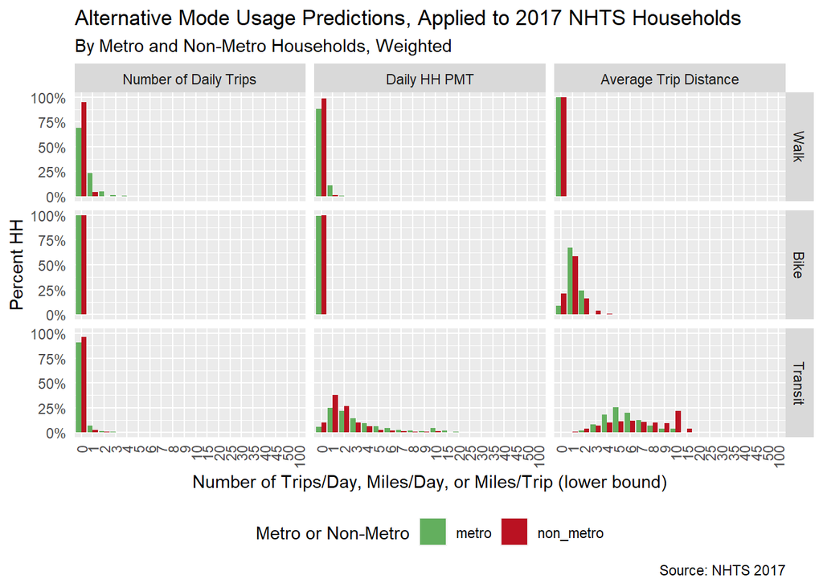

Figure 3: Alt Mode Usage Distributions, Model Prediction